# NWUDO CHIKAEZE FIDELIS JUNIOR 202290064

## QUESTION 1

Load the given EPA fuel economy data set into a pandas dataframe. Write code which removes the non-numeric columns from the data frame. Create a new column named “CityHighwayDiff” which is calculated by taking the difference of the “city08” column and “highway08” column. Plot a histogram of this column.

```python
import pandas as pd
import matplotlib.pyplot as plt
import numpy as np
from sklearn.model_selection import train_test_split
from sklearn.linear_model import LogisticRegression
from sklearn.metrics import mean_absolute_error
from sklearn.metrics import mean_squared_error
import matplotlib.pyplot as plt
import seaborn as sns
```

```python
df = pd.read_csv("EPA fuel economy dataset.csv")
df
```

|  | city08 | cityA08 | cylinders | fuelType | fuelType1 | highway08 | highwayA08 | id | make | model | mpgData | trany | year | fuelType2 |
| --- | --- | --- | --- | --- | --- | --- | --- | --- | --- | --- | --- | --- | --- | --- |
| 0 | 19 | 0 | 4 | Regular | Regular Gasoline | 25 | 0 | 1 | Alfa Romeo | Spider Veloce 2000 | Y | Manual 5-spd | 1985 | NaN |
| 1 | 9 | 0 | 12 | Regular | Regular Gasoline | 14 | 0 | 10 | Ferrari | Testarossa | N | Manual 5-spd | 1985 | NaN |
| 2 | 23 | 0 | 4 | Regular | Regular Gasoline | 33 | 0 | 100 | Dodge | Charger | Y | Manual 5-spd | 1985 | NaN |
| 3 | 10 | 0 | 8 | Regular | Regular Gasoline | 12 | 0 | 1000 | Dodge | B150/B250 Wagon 2WD | N | Automatic 3-spd | 1985 | NaN |
| 4 | 17 | 0 | 4 | Premium | Premium Gasoline | 23 | 0 | 10000 | Subaru | Legacy AWD Turbo | N | Manual 5-spd | 1993 | NaN |
| ... | ... | ... | ... | ... | ... | ... | ... | ... | ... | ... | ... | ... | ... | ... |
| 5995 | 13 | 0 | 6 | Regular | Regular Gasoline | 18 | 0 | 15395 | Chevrolet | Express 1500/2500 2WD | N | Automatic 4-spd | 1999 | NaN |
| 5996 | 13 | 0 | 8 | Regular | Regular Gasoline | 16 | 0 | 15396 | Chevrolet | Express 1500/2500 2WD | Y | Automatic 4-spd | 1999 | NaN |
| 5997 | 12 | 0 | 8 | Regular | Regular Gasoline | 17 | 0 | 15397 | Chevrolet | Express 1500/2500 2WD | Y | Automatic 4-spd | 1999 | NaN |
| 5998 | 13 | 0 | 6 | Regular | Regular Gasoline | 15 | 0 | 15398 | Dodge | B1500 Wagon 2WD | N | Automatic 3-spd | 1999 | NaN |
| 5999 | 12 | 0 | 8 | Regular | Regular Gasoline | 18 | 0 | 15399 | Dodge | B1500 Wagon 2WD | N | Automatic 4-spd | 1999 | NaN |

6000 rows × 14 columns

```python
df = df.drop(columns=["fuelType","fuelType1","make","model","trany","mpgData", "fuelType2"])
CityHighwayDiff = df.highway08 - df.city08
df["CityHighwayDiff"] = CityHighwayDiff
df
```

|  | city08 | cityA08 | cylinders | highway08 | highwayA08 | id | year | CityHighwayDiff |
| --- | --- | --- | --- | --- | --- | --- | --- | --- |
| 0 | 19 | 0 | 4 | 25 | 0 | 1 | 1985 | 6 |
| 1 | 9 | 0 | 12 | 14 | 0 | 10 | 1985 | 5 |
| 2 | 23 | 0 | 4 | 33 | 0 | 100 | 1985 | 10 |
| 3 | 10 | 0 | 8 | 12 | 0 | 1000 | 1985 | 2 |
| 4 | 17 | 0 | 4 | 23 | 0 | 10000 | 1993 | 6 |
| ... | ... | ... | ... | ... | ... | ... | ... | ... |
| 5995 | 13 | 0 | 6 | 18 | 0 | 15395 | 1999 | 5 |
| 5996 | 13 | 0 | 8 | 16 | 0 | 15396 | 1999 | 3 |
| 5997 | 12 | 0 | 8 | 17 | 0 | 15397 | 1999 | 5 |
| 5998 | 13 | 0 | 6 | 15 | 0 | 15398 | 1999 | 2 |
| 5999 | 12 | 0 | 8 | 18 | 0 | 15399 | 1999 | 6 |

6000 rows × 8 columns

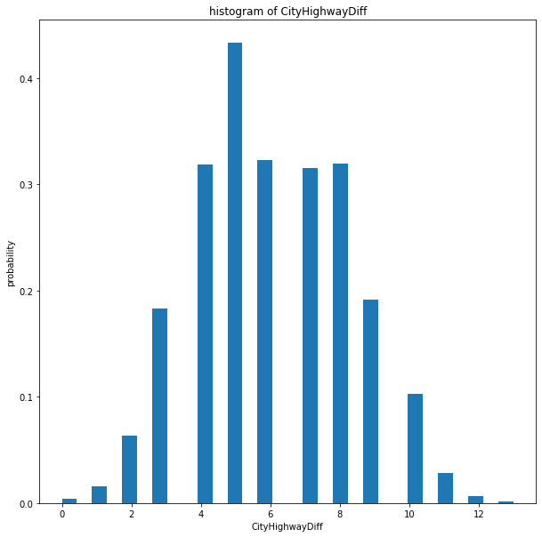

```python
fig= plt.figure(figsize=(10,10))
hist = plt.hist(df["CityHighwayDiff"], density=True, bins=30 )
plt.xlabel("CityHighwayDiff")
plt.ylabel("probability")
plt.title("histogram of CityHighwayDiff")
plt.show()
```

## QUESTION 2

Using the EPA fuel economy data set. Consider the “year” column. Create a new column “Decade” from the year column which maps each year into a class based on its decade. Plot a histogram of the Decade column to visualize the occurrences in each of the decades. Remove any other non-numeric columns from the dataframe. With the columns remaining, create a linear classifier that predicts the decade of a particular car based on the rest of the columns. Train the classifier using the entire dataset. Calculate and print the training error of the resulting classifier.

```python
df2= pd.read_csv("EPA fuel economy dataset.csv")
df2["decade"] = [ int(np.floor(year/10) * 10) for year in df2["year"]]
df2
```

|  | city08 | cityA08 | cylinders | fuelType | fuelType1 | highway08 | highwayA08 | id | make | model | mpgData | trany | year | fuelType2 | decade |
| --- | --- | --- | --- | --- | --- | --- | --- | --- | --- | --- | --- | --- | --- | --- | --- |
| 0 | 19 | 0 | 4 | Regular | Regular Gasoline | 25 | 0 | 1 | Alfa Romeo | Spider Veloce 2000 | Y | Manual 5-spd | 1985 | NaN | 1980 |
| 1 | 9 | 0 | 12 | Regular | Regular Gasoline | 14 | 0 | 10 | Ferrari | Testarossa | N | Manual 5-spd | 1985 | NaN | 1980 |
| 2 | 23 | 0 | 4 | Regular | Regular Gasoline | 33 | 0 | 100 | Dodge | Charger | Y | Manual 5-spd | 1985 | NaN | 1980 |
| 3 | 10 | 0 | 8 | Regular | Regular Gasoline | 12 | 0 | 1000 | Dodge | B150/B250 Wagon 2WD | N | Automatic 3-spd | 1985 | NaN | 1980 |
| 4 | 17 | 0 | 4 | Premium | Premium Gasoline | 23 | 0 | 10000 | Subaru | Legacy AWD Turbo | N | Manual 5-spd | 1993 | NaN | 1990 |
| ... | ... | ... | ... | ... | ... | ... | ... | ... | ... | ... | ... | ... | ... | ... | ... |
| 5995 | 13 | 0 | 6 | Regular | Regular Gasoline | 18 | 0 | 15395 | Chevrolet | Express 1500/2500 2WD | N | Automatic 4-spd | 1999 | NaN | 1990 |
| 5996 | 13 | 0 | 8 | Regular | Regular Gasoline | 16 | 0 | 15396 | Chevrolet | Express 1500/2500 2WD | Y | Automatic 4-spd | 1999 | NaN | 1990 |
| 5997 | 12 | 0 | 8 | Regular | Regular Gasoline | 17 | 0 | 15397 | Chevrolet | Express 1500/2500 2WD | Y | Automatic 4-spd | 1999 | NaN | 1990 |
| 5998 | 13 | 0 | 6 | Regular | Regular Gasoline | 15 | 0 | 15398 | Dodge | B1500 Wagon 2WD | N | Automatic 3-spd | 1999 | NaN | 1990 |
| 5999 | 12 | 0 | 8 | Regular | Regular Gasoline | 18 | 0 | 15399 | Dodge | B1500 Wagon 2WD | N | Automatic 4-spd | 1999 | NaN | 1990 |

6000 rows × 15 columns

```python
print(df2.decade.unique())
```

```
[1980 1990]
```

```
1990    5399
1980     601
Name: decade, dtype: int64
```

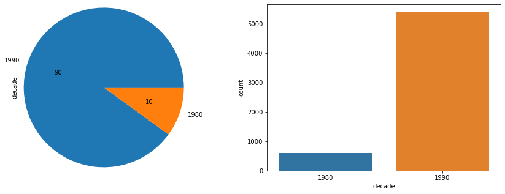

```python
plt.figure(figsize = (15,5))
plt.subplot(121)
my_explode = [0,0]
df2['decade'].value_counts().plot(kind ='pie',autopct = '%2.f',explode = my_explode,radius = 1.2)
plt.subplot(122)
sns.countplot(data = df2, x = 'decade')
df2['decade'].value_counts()
```

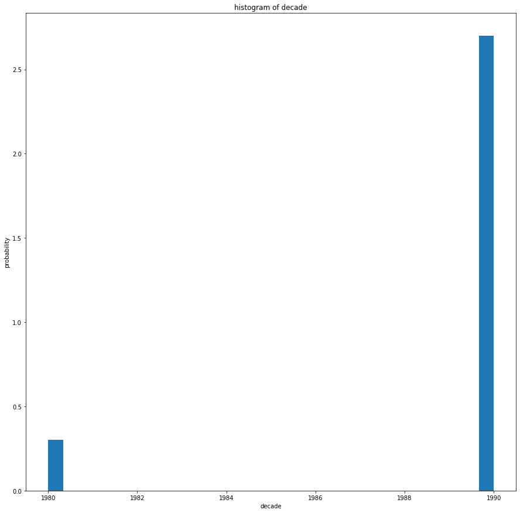

```python
fig= plt.figure(figsize=(15,15))
hist = plt.hist(df2["decade"], density=True, bins=30 )
plt.xlabel("decade")
plt.ylabel("probability")
plt.title("histogram of decade")
plt.show()
```

```python
df3 = df2.drop(columns=["fuelType","fuelType1","make","model","trany","mpgData", "fuelType2"])
Y=df2['decade'].values
X=df[['city08','cityA08','cylinders','highway08','highwayA08','id','year']].values
model = LogisticRegression(random_state=0)
clf = model.fit(X, Y)
y_pred1 = model.predict(X)
pred_diff = y_pred1 - Y
training_error = np.mean(np.square(np.array(y_pred1)-np.array(Y)))
testing_error = np.mean(Y - y_pred1)

print(model.score(X,Y))
print(y_pred1)
print(pred_diff)
print("training error=", training_error)
print("testing error=", testing_error)
```

```
1.0
[1980 1980 1980 ... 1990 1990 1990]
[0 0 0 ... 0 0 0]
training error= 0.0
testing error= 0.0
```

## QUESTION 3

Building on 3, split the training set used into a training and test set (split evenly 50:50). Re-fit the linear classifier developed above on the 50% training set and calculate and print the mean absolute error of the predictor using the 50% test set.

```python
X_train, X_test, Y_train, Y_test = train_test_split(X, Y, test_size = 0.5, random_state = 0)
model.fit(X_train, Y_train)
Y_pred2 = model.predict(X_test)
mae = mean_absolute_error(Y_test, Y_pred2)
training_error1 = np.mean(np.square(np.array(y_pred2)-np.array(Y_train)))



print("mean absolute error = ", mae)
print("training error=", training_error1)
```

```
mean absolute error =  0.0
training error= 18.1
```

## QUESTION 4

Pick 2 of the numeric columns of the dataframe to eliminate from the table. Re-train the classifier using this new dataset. Compare the testing and training error using the 50/50 split of the missing columns classifier with that containing the full set of columns.

```python
df2.nunique().sort_values(ascending=True)
```

```
fuelType2        0
cityA08          1
highwayA08       1
mpgData          2
decade           2
fuelType         4
fuelType1        4
cylinders        8
year             8
trany           10
city08          34
highway08       40
make            58
model          868
id            6000
dtype: int64
```

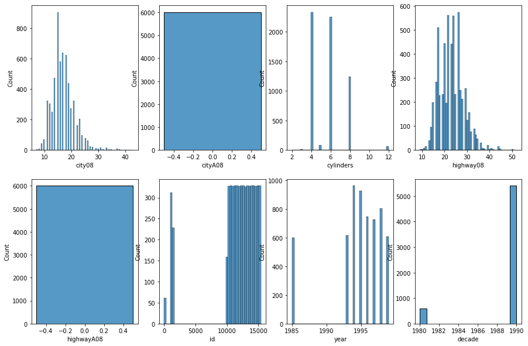

```python
j=1
fig = plt.figure(figsize = (15,10))
for i in df3.columns:
    plt.subplot(2,4,j)
    sns.histplot(df3[i])
    j=j+1
```

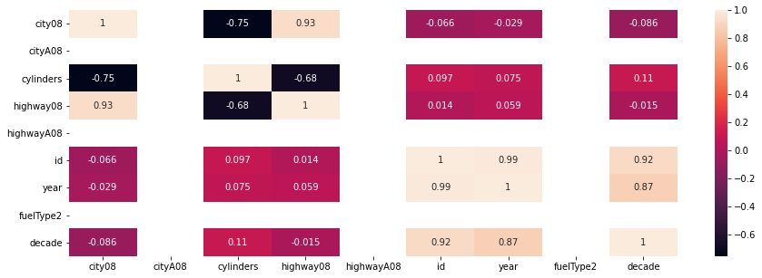

```python
plt.figure(figsize = (15,5))
corr = df2.corr()
sns.heatmap(corr,annot = True)
```

```python
from sklearn.feature_selection import VarianceThreshold
X=df2[['city08','cityA08','cylinders','highway08','highwayA08','id','year']].values
sel = VarianceThreshold(threshold=(.8 * (1 - .8)))
sel.fit_transform(X)
```

```
array([[   19,     4,    25,     1,  1985],
       [    9,    12,    14,    10,  1985],
       [   23,     4,    33,   100,  1985],
       ...,
       [   12,     8,    17, 15397,  1999],
       [   13,     6,    15, 15398,  1999],
       [   12,     8,    18, 15399,  1999]], dtype=int64)
```

### Dimensionality reduction: Under feature selection, we could delete the features with very low variation. That is, features that have the same value in all samples. From our data, "cityA08" and "highwayA08" are the two features with low variation.

```python
Y=df2['decade'].values
Xnew=df2[['city08','cylinders','highway08','id','year']].values
print(Y)
print(Xnew)
print(Y.shape)
print(Xnew.shape)
```

```
[1980 1980 1980 ... 1990 1990 1990]
[[   19     4    25     1  1985]
 [    9    12    14    10  1985]
 [   23     4    33   100  1985]
 ...
 [   12     8    17 15397  1999]
 [   13     6    15 15398  1999]
 [   12     8    18 15399  1999]]
(6000,)
(6000, 5)
```

```python
X_train2, X_test2, Y_train2, Y_test2 = train_test_split(Xnew, Y, test_size = 0.5, random_state = 0)
model.fit(X_train2, Y_train2)
y_pred3 = model.predict(X_test2)
mae = mean_absolute_error(Y_test2, y_pred3)
mse = mean_squared_error(Y_test2, y_pred3)
training_error2 = np.mean(np.square(np.array(y_pred3)-np.array(Y_train2)))
testing_error2 = np.mean(Y_test2 - y_pred3)


#print(y_pred3)
#print(mae)
print("training error=",training_error2)
print("testing error=",testing_error2)
```

```
training error= 18.1
testing error= 0.0
```

Comparing the training and testing error for the full set of columns and that with two columns taken off, I can conclude that the two columns had little or no impact at all on the the performance of the model.